# APIs: From JSON to Tibble

Lecture 09a  
POLS 6394 · Tuesday, October 20

## Today

- What an **API** is, and what comes back when you ask one a question
- **JSON**: objects and arrays, and how R reads them
- Tour three APIs: JSONPlaceholder, the Federal Register, and the World Bank
- Turning a nested response into a **tibble**, one step at a time
- Lab: congressional polling data, from JSON to a figure

# What an API is

## The job

Many organizations publish data that you can see on a website but can’t download as a file. An **API** (application programming interface) is a way for your code, rather than your browser, to ask for it.

- You send a **request**: a web address plus a few details about what you want.
- The server sends back a **response**: the data, as text.
- Your job is to turn that text into a tibble.

## Anatomy of a request

A request is a web address with a question attached:

```
https://www.federalregister.gov/api/v1/documents.json
  ?per_page=10
  &order=oldest
```

- The first line is the **endpoint**: which server and which kind of data.
- `?` starts the question. Everything after it is **parameters**.
- Each parameter is a name and a value: `per_page=10`.
- `&` separates one parameter from the next.

## Each API is different

Each service names its options and organizes its data differently. Working with a new API usually involves both documentation and experimentation:

1. **Read the documentation:** find the address and how to ask for the data you want.
2. **Try a small request:** look at what comes back before requesting more.
3. **Adjust and inspect again:** change one option at a time until you can extract what you need.

## What comes back: JSON

Most APIs reply in **JSON**. An **object** groups named values inside braces, `{ }`:

```json
{
  "id": 145,
  "name": "Environmental Protection Agency"
}
```

- A colon links a name to its value; commas separate the entries.
- Names and text values use double quotes. Numbers don’t need quotes.
- Indentation makes the structure easier to read; it doesn’t change the data.

## An array of objects

An **array**, `[ ]`, is an ordered collection. Here it holds two agency objects:

```json
[
  {
    "id": 145,
    "name": "Environmental Protection Agency"
  },
  {
    "id": 159,
    "name": "Federal Aviation Administration"
  }
]
```

Objects and arrays can nest inside each other.

# Reading JSON in R

## Setup

Run this chunk as written. jsonlite reads JSON; httr2 sends web requests. lubridate and scales support the plotting examples.

```r
library(tidyverse)
library(jsonlite)
library(httr2)
library(lubridate)
library(scales)
```

## A tiny JSON object

JSON is text, so in R it starts out as a string. Single quotes outside let the double quotes inside stay as they are.

```r
agency_json <- '{
  "id": 145,
  "name": "Environmental Protection Agency",
  "short_name": "EPA"
}'
class(agency_json)
```

```
[1] "character"
```

R sees only characters here. It doesn’t yet know there’s a name or an id.

## Parse it: `fromJSON()`

jsonlite’s `fromJSON()` reads JSON text and returns an R object. A JSON **object** becomes a **named list**, and `$` reads it, as in 07b.

```r
agency <- fromJSON(agency_json)
agency
```

```
$id
[1] 145

$name
[1] "Environmental Protection Agency"

$short_name
[1] "EPA"
```

## Read it with `$`

`$` reads a named item from the list.

```r
agency$name
```

```
[1] "Environmental Protection Agency"
```

```r
agency$id
```

```
[1] 145
```

## Objects and arrays in R

| In JSON | In R |
| --- | --- |
| object `{ }` | named list (read with `$`) |
| array `[ ]` of values | vector |
| array `[ ]` of objects | list of records, or a data frame (more soon) |

JSON stores data as text. We’ll read that text and arrange the records into rows and columns.

# A practice API

## JSONPlaceholder

[JSONPlaceholder](https://jsonplaceholder.typicode.com) is a free practice API with made-up users, posts, and to-do items. No key is needed.

Open this address in your browser: jsonplaceholder.typicode.com/users.

- The browser sends a web request and displays the JSON response directly.
- Look at the outer `[ ]`, then the first user’s `name`, `address`, and `company`.
- The server returns data rather than an HTML page. Your browser may format the JSON for you.

## Make the same request from R

`fromJSON()` accepts the same web address. R requests the JSON and parses it into an R object instead of displaying it in a browser.

```r
users <- fromJSON("https://jsonplaceholder.typicode.com/users")
```

Keep live calls disabled during rendering; run them in the Console to try them. `fromJSON()` also reads a saved file:

```r
users <- fromJSON("Data/practice/users.json")
```

## Print the users

Print `users` as a tibble to inspect the ten records.

```r
as_tibble(users)
```

```
# A tibble: 10 × 8
      id name           username email address$street phone website company$name
   <int> <chr>          <chr>    <chr> <chr>          <chr> <chr>   <chr>
 1     1 Leanne Graham  Bret     Sinc… Kulas Light    1-77… hildeg… Romaguera-C…
 2     2 Ervin Howell   Antonet… Shan… Victor Plains  010-… anasta… Deckow-Crist
 3     3 Clementine Ba… Samantha Nath… Douglas Exten… 1-46… ramiro… Romaguera-J…
 4     4 Patricia Lebs… Karianne Juli… Hoeger Mall    493-… kale.b… Robel-Corke…
 5     5 Chelsey Dietr… Kamren   Luci… Skiles Walks   (254… demarc… Keebler LLC
 6     6 Mrs. Dennis S… Leopold… Karl… Norberto Cros… 1-47… ola.org Considine-L…
 7     7 Kurtis Weissn… Elwyn.S… Tell… Rex Trail      210.… elvis.… Johns Group
 8     8 Nicholas Runo… Maxime_… Sher… Ellsworth Sum… 586.… jacynt… Abernathy G…
 9     9 Glenna Reiche… Delphine Chai… Dayna Park     (775… conrad… Yost and So…
10    10 Clementina Du… Moriah.… Rey.… Kattie Turnpi… 024-… ambros… Hoeger LLC
# ℹ 6 more variables: address$suite <chr>, $city <chr>, $zipcode <chr>,
#   $geo <df[,2]>, company$catchPhrase <chr>, $bs <chr>
```

Each row is one user. `address` and `company` contain additional fields; we’ll inspect those next.

## Names and columns

```r
class(users)
```

```
[1] "data.frame"
```

```r
names(users)
```

```
[1] "id"       "name"     "username" "email"    "address"  "phone"    "website"
[8] "company"
```

```r
users$name[1:3]
```

```
[1] "Leanne Graham"    "Ervin Howell"     "Clementine Bauch"
```

## A column that holds a table

Each user’s `address` is an object of its own, so `address` is a data frame inside the data frame.

```r
names(users$address)
```

```
[1] "street"  "suite"   "city"    "zipcode" "geo"
```

```r
users$address$city[1:3]
```

```
[1] "Gwenborough"   "Wisokyburgh"   "McKenziehaven"
```

Two `$` reach inside: first the column, then the name within it.

## Your Turn: inside a nested column

*~2 minutes. Quick check.*

`company` is nested too. Use `names()` to see what’s in it, then use **two** `$` to pull out every user’s company name.

```r
names(users$___)
users$___$___
```

# What happens inside a call

## One line, three jobs

`fromJSON("https://...")` did three jobs at once:

1. **Send** the request to the server.
2. **Check** the status code the server sent back.
3. **Parse** the body, the JSON text, into R.

httr2 makes real **HTTP requests over the internet**, using the same protocol as your browser. We’ll take one call apart to see the request and response.

## Send it

`request()` prepares the request in R; `req_perform()` actually contacts the web server and retrieves its response. No browser window opens.

```r
resp <- request("https://jsonplaceholder.typicode.com/users") |>
  req_perform()
resp
resp_status(resp)
```

```
<httr2_response>
GET https://jsonplaceholder.typicode.com/users
Status: 200 OK
Content-Type: application/json
Body: In memory (5645 bytes)
```

The block above is canned output. **Status 200** means OK. `resp_status()` extracts that number; the content type says the body is JSON.

## The body is just text

```r
resp_body_string(resp) |> str_sub(1, 110)
```

```
[1] "[\n  {\n    \"id\": 1,\n    \"name\": \"Leanne Graham\",\n    \"username\": \"Bret\",\n    \"email\": \"Sincere@april.biz\","
```

The response body is a string containing JSON text. `\n` is a line break and `\"` is a quotation mark inside the string. `fromJSON()` parses this text into lists, vectors, or data frames.

## When it fails: 404

A wrong address gets a different status code. `fromJSON()` stops:

```r
fromJSON("https://jsonplaceholder.typicode.com/nope")
```

```
Error in open.connection(con, "rb") :
  cannot open the connection to 'https://jsonplaceholder.typicode.com/nope'
In addition: Warning message:
  cannot open URL 'https://jsonplaceholder.typicode.com/nope': HTTP status was '404 Not Found'
```

- **2xx** (usually 200): it worked.
- **4xx**: the request was rejected, for example a bad address (404), missing key (401), or too many requests (429).
- **5xx**: the server had trouble. Try again later.

## Back to one line

jsonlite handles much of the lower-level web work for us. With a URL, `fromJSON()` sends the request, downloads the response, and parses the JSON into an R object—all in one call.

Use httr2 when you need more control over the request or want to inspect the response. For these examples, `fromJSON()` is enough; it also reads saved JSON files.

# Two shapes for the same records

## Three agencies, flat

A JSON array of three flat records, all with the same names:

```r
agencies_json <- '[
  {"id": 145, "name": "Environmental Protection Agency", "short_name": "EPA"},
  {"id": 159, "name": "Federal Aviation Administration", "short_name": "FAA"},
  {"id": 53, "name": "Coast Guard", "short_name": "USCG"}
]'
```

```r
fromJSON(agencies_json) |> as_tibble()
```

```
# A tibble: 3 × 3
     id name                            short_name
  <int> <chr>                           <chr>
1   145 Environmental Protection Agency EPA
2   159 Federal Aviation Administration FAA
3    53 Coast Guard                     USCG
```

By default `fromJSON()` **simplifies**: an array of same-shaped objects becomes a data frame, as the users did. `as_tibble()` makes it a tibble.

## Same text, simplifyVector = FALSE

`simplifyVector = FALSE` switches the simplifying off:

```r
records <- fromJSON(agencies_json, simplifyVector = FALSE)
class(records)
```

```
[1] "list"
```

```r
length(records)
```

```
[1] 3
```

```r
records[[1]]$name
```

```
[1] "Environmental Protection Agency"
```

Now you have a **list of records**, one named list per JSON object.

## Why we standardize on FALSE

- With the default, the result’s shape depends on the data. Flat records give a data frame; records with arrays inside give something messier.
- With `simplifyVector = FALSE`, objects are always named lists and arrays are always lists. You learn the shape once.

From here on every `fromJSON()` call on API data uses `simplifyVector = FALSE`.

# A real API: the Federal Register

## Our API

The Federal Register is the government’s daily journal. Agencies publish **rules**, **proposed rules**, and **notices** in it.

- Free, and **no key required**.
- One unit to remember: a **document** (a rule, a proposed rule, or a notice).
- A document can come from **more than one agency**. That detail matters later.

## Build the address

`paste0()` (from 07b) glues the pieces together with nothing between them. One parameter per line:

```r
rules_url <- paste0(
  "https://www.federalregister.gov/api/v1/documents.json",
  "?conditions[type][]=RULE",
  "&conditions[publication_date][gte]=2026-09-14",
  "&conditions[publication_date][lte]=2026-09-16",
  "&per_page=10&order=oldest",
  "&fields[]=document_number&fields[]=title&fields[]=type",
  "&fields[]=publication_date&fields[]=agencies"
)
```

## Reading the address

- `conditions[type][]=RULE`: rules only. The brackets are this API’s spelling; copy them as written.
- `publication_date`: September 14–16, inclusive. `gte` means on or after; `lte` means on or before.
- `per_page=10&order=oldest`: ten documents, oldest first. `fields[]=...` selects which fields to return.

The API’s documentation lists every parameter it accepts. You copy their spelling; you don’t invent it.

## Read the response

The response contains the records plus search information, called an **envelope**. Inspect both.

```r
docs <- fromJSON(rules_url, simplifyVector = FALSE)
```

For rendering, read the copy saved on October 12:

```r
docs <- fromJSON("Data/fedreg/documents_rules.json", simplifyVector = FALSE)
names(docs)
```

```
[1] "description"   "count"         "total_pages"   "next_page_url"
[5] "results"
```

```r
docs$count
```

```
[1] 24
```

```r
docs$total_pages
```

```
[1] 3
```

```r
length(docs$results)
```

```
[1] 10
```

`results` holds the document records. `count` and `total_pages` describe the search: **24 matches, 10 received**. They aren’t document columns.

## Your Turn: read an envelope

*~3 minutes*

Same request, but for proposed rules (type `PRORULE`). I saved the response in `Data/fedreg/documents_prorules.json`. Pull the metadata out of the envelope.

```r
prop <- fromJSON("Data/fedreg/documents_prorules.json", simplifyVector = FALSE)
prop$___
prop$___
length(prop$___)
```

How many proposed rules matched in all, and how many records did we receive?

# Unpack the document records

## Look inside the first record

Before reshaping `docs$results`, inspect one record. `[[1]]` selects the first document; `str()` shows its structure, and `max.level = 1` keeps nested agency details collapsed.

```r
str(docs$results[[1]], max.level = 1)
```

```
List of 5
 $ document_number : chr "2026-18734"
 $ title           : chr "Safety Zone; Lake Erie, Oregon, OH"
 $ type            : chr "Rule"
 $ publication_date: chr "2026-09-14"
 $ agencies        :List of 2
```

The named fields will become columns. `agencies` contains another list, which we’ll unpack separately.

## Three steps

1. Give each document’s fields their own columns.
2. Give each agency its own row.
3. Give each agency’s fields their own columns.

We’ll run each step and inspect its output.

## Step 1: document fields as columns

`docs$results` is a list of ten records. `tibble(record = ...)` puts one whole record in each cell of a column called `record`. `unnest_wider()` then gives each name inside the cells its own column.

```r
documents <- tibble(record = docs$results) |>
  unnest_wider(record)
```

```r
set.seed(6394)
documents |>
  slice_sample(n = 5) |>
  select(document_number, type, publication_date, agencies)
```

```
# A tibble: 5 × 4
  document_number type  publication_date agencies
  <chr>           <chr> <chr>            <list>
1 2026-18778      Rule  2026-09-14       <list [1]>
2 2026-18780      Rule  2026-09-14       <list [1]>
3 2026-18830      Rule  2026-09-15       <list [1]>
4 2026-18776      Rule  2026-09-14       <list [2]>
5 2026-18734      Rule  2026-09-14       <list [2]>
```

One row is one **document**. `agencies` is still a list column: each cell holds that document’s agencies. Some documents list several agencies in that cell.

## Step 2: one row per agency

Before running the next chunk: there are 10 documents. Will the result have more rows, fewer rows, or the same number?

`unnest_longer(agencies)` makes one row for each item in the list column.

```r
nrow(documents)
```

```
[1] 10
```

```r
doc_agency <- documents |>
  unnest_longer(agencies)

nrow(doc_agency)
```

```
[1] 16
```

## Step 3: agency fields as columns

Each `agencies` cell is a record. `names_sep = "_"` puts the column name in front of each new column, so `name` becomes `agencies_name`.

```r
doc_agency <- doc_agency |>
  unnest_wider(agencies, names_sep = "_")

set.seed(6394)
doc_agency |>
  slice_sample(n = 5) |>
  select(document_number, agencies_name, agencies_id)
```

```
# A tibble: 5 × 3
  document_number agencies_name                   agencies_id
  <chr>           <chr>                                 <int>
1 2026-18848      Federal Aviation Administration         159
2 2026-18830      Environmental Protection Agency         145
3 2026-18766      Comptroller of the Currency              80
4 2026-18766      Federal Reserve System                  188
5 2026-18800      Personnel Management Office             406
```

Each row now identifies a document and one of its agencies.

## The unit changed

- Before: one row is a **document**. 10 rows.
- After: one row is a **document-agency pair**. 16 rows.

The same document can now appear on several rows. To count documents, count distinct document numbers:

```r
n_distinct(doc_agency$document_number)
```

```
[1] 10
```

Counting rows now counts document-agency pairs, not documents.

# A third API: the World Bank

## World Bank population data

*Guided demonstration: run the supplied code as written.*

The [World Bank API](https://datahelpdesk.worldbank.org/knowledgebase/articles/889392) provides international development indicators without a key. We’ll compare population in Brazil, India, Mexico, and the United States.

```r
wb_url <- paste0(
  "https://api.worldbank.org/v2/country/USA;MEX;BRA;IND",
  "/indicator/SP.POP.TOTL",
  "?format=json&date=2000:2023&per_page=100"
)
```

`;` separates countries; `SP.POP.TOTL` means total population. The parameters request JSON, years 2000–2023, and up to 100 records.

## An envelope without names

Run the live call in the Console if you want to try it; keep it disabled during rendering. The next chunk reads the saved response.

```r
wb <- fromJSON(wb_url, simplifyVector = FALSE)
```

```r
wb <- fromJSON("Data/worldbank/population_2000_2023.json",
               simplifyVector = FALSE)
wb[[1]]$pages
```

```
[1] 1
```

```r
length(wb[[2]])
```

```
[1] 96
```

The outer array has two elements: `[[1]]` is metadata and `[[2]]` holds the records. There is one page with 96 records: four countries × 24 years.

## One row per country-year

Unpack the records and the nested country names, then turn each year into a January 1 date. The values are annual totals, not daily measurements.

```r
population <- tibble(record = wb[[2]]) |>
  unnest_wider(record) |>
  unnest_wider(country, names_sep = "_") |>
  transmute(
    country = country_value,
    date = make_date(as.integer(date)),
    population = value
  )
```

Recall `transmute()` and lubridate’s `make_date()` from 05a: keep the named columns and build dates from the years. Here `as.integer()` converts the year text first.

## Compare population trends

A line connects the annual observations for each country. Reuse scales’ `label_number()` for millions and `scale_x_date()` for year ticks (06a).

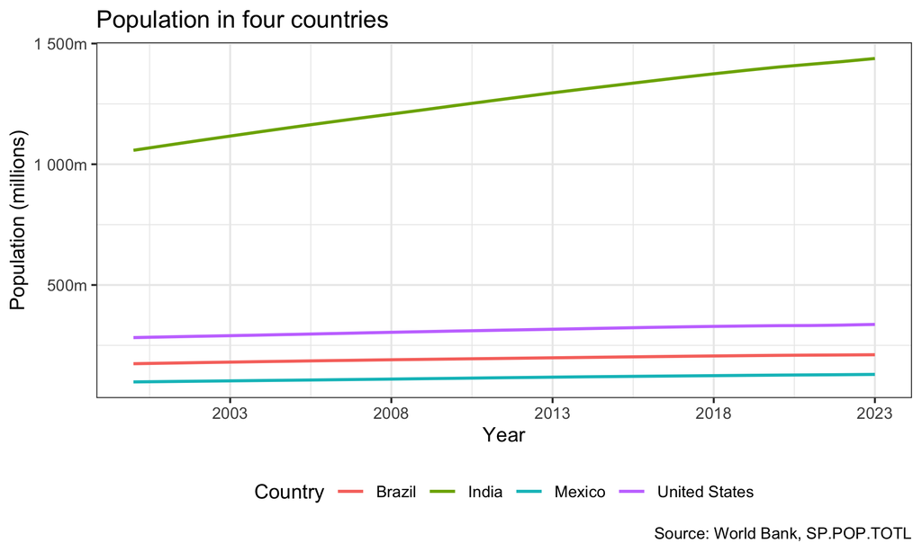

```r
population_plot <- ggplot(
  population,
  aes(x = date, y = population, color = country)
) +
  geom_line(linewidth = 0.8) +
  scale_y_continuous(
    labels = label_number(scale = 1e-6, suffix = "m")
  ) +
  scale_x_date(
    date_breaks = "5 years", date_labels = "%Y"
  ) +
  labs(
    title = "Population in four countries",
    x = "Year", y = "Population (millions)",
    color = "Country",
    caption = "Source: World Bank, SP.POP.TOTL"
  ) +
  theme_bw() +
  theme(legend.position = "bottom")
population_plot
```

India dominates the shared scale. Comparing growth instead of size would need percentage changes or another relative measure.

# Lab

## Lab: the generic ballot

The **generic ballot** asks which party people would vote for in their House race, without naming candidates. **VoteHub** supplies the polls. Democratic margin = Democratic percentage − Republican percentage.

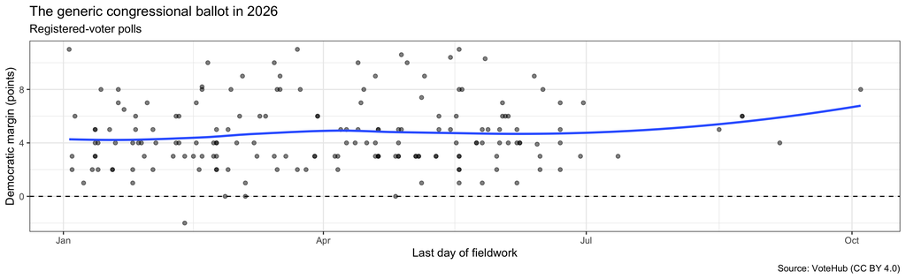

The line is a smoother that counts every poll equally. It describes these points; it isn’t a polling average.

## Lab: read the polls

Build the VoteHub address, then pass it to jsonlite’s `fromJSON()` to request generic-ballot polls for January 1–October 16.

```r
ballot_url <- paste0(
  "https://api.votehub.com/polls",
  "?poll_type=generic-ballot",
  "&from_date=2026-01-01&to_date=2026-10-16"
)
```

```r
polls <- fromJSON(ballot_url, simplifyVector = FALSE)
```

`paste0()` only builds the address; `fromJSON()` makes the web request. `simplifyVector = FALSE` keeps each poll as a list. Run live calls in the Console; for rendering, load the saved response:

```r
polls <- fromJSON(
  "Data/votehub/generic_ballot_2026.json",
  simplifyVector = FALSE
)
```

## Lab: one poll

Unlike the Federal Register, this response has **no envelope**: the array itself holds the polls.

```r
length(polls)
```

```
[1] 307
```

```r
names(polls[[1]])
```

```
 [1] "id"          "poll_type"   "sample_size" "population"  "url"
 [6] "created_at"  "start_date"  "end_date"    "pollster"    "answers"
[11] "seat_name"   "sponsors"    "internal"    "partisan"    "subject"
```

```r
str(polls[[1]]$answers)
```

```
List of 2
 $ :List of 2
  ..$ choice: chr "Rep"
  ..$ pct   : num 44.2
 $ :List of 2
  ..$ choice: chr "Dem"
  ..$ pct   : num 48.2
```

`length()` counts polls; `names(polls[[1]])` lists the first poll’s fields. `str(polls[[1]]$answers)` shows the structure and values inside its answers.

`pollster`, `end_date`, and `population` describe the survey. Each `answers` record has a party (`choice`) and percentage (`pct`). Their order varies: use the party names, not positions.

## Lab: your tasks

*~3 minutes together, then ~15 minutes on your own.* Start in class; finish by 7:00 PM Wednesday, October 21.

1. **Read and inspect** (worked, ~2 minutes): run the supplied cached import and inspection in the workbook. The URL and optional live call are there for reference.
2. **Reshape** (half-worked, ~7 minutes), in two steps: `unnest_longer()` and `unnest_wider()` give one row per poll and party; then `pivot_wider()` (04b) gives one row per poll, with a `Dem` column and a `Rep` column.
3. **Plot** (half-worked, ~6 minutes): the Democratic margin over time for registered-voter polls, with points and a smoother. Give it a title that says what it shows.

## Before Next Class

Save, render, inspect your changes, commit, push, and confirm the commit on GitHub. If unfinished code stops the render, put `#| eval: false` back on that chunk and still push.

- **By 7:00 PM Wednesday, October 21:** finish the lab and push.
- **Problem Set 04** is a practice midterm: optional and ungraded, with nothing to submit. Try it under midterm conditions: 40 minutes, alone, no AI.
- **Thursday, October 22:** APIs II, keys and many requests.
- **Before Thursday:** register for a free Congress.gov API key at https://api.congress.gov/sign-up/. The key arrives by email, so don’t wait until class. Keep it to yourself and don’t paste it into any file yet.
- Request your Census key too; [signup instructions are on the class board](https://github.com/uh-pols6394-fall26/course-discussions/discussions/8). Hold off on LegiScan for now.

# If Time Remains

## Extension 1a: back to one row per document

*~10 minutes.*

`doc_agency` has one row per document-agency pair. Collapse it to one row per document, with the agencies joined into one string. stringr’s `str_flatten()` joins the pieces with whatever separator you pick.

```r
doc_agency |>
  group_by(document_number) |>
  summarize(
    n_agencies = n(),
    agencies = str_flatten(agencies_name, collapse = ___)
  ) |>
  arrange(desc(___))
```

The result should have the same number of rows as `documents`, because the unit is a document again. Check:

```r
nrow(documents)
```

```
[1] 10
```

## Extension 1b: when a document has no agency

Sometimes `agencies` is an empty array. Here’s a made-up pair of documents (the real ones this week all have an agency):

```r
empty_json <- '[
  {"document_number": "A-1", "agencies": [{"name": "Coast Guard"}, {"name": "Treasury Department"}]},
  {"document_number": "A-2", "agencies": []}
]'
empty <- tibble(record = fromJSON(empty_json, simplifyVector = FALSE)) |>
  unnest_wider(record)
```

## Extension 1c: keep documents with no agencies

```r
empty |> unnest_longer(agencies)
```

```
# A tibble: 2 × 2
  document_number agencies
  <chr>           <list>
1 A-1             <named list [1]>
2 A-1             <named list [1]>
```

```r
empty |> unnest_longer(agencies, keep_empty = TRUE)
```

```
# A tibble: 3 × 2
  document_number agencies
  <chr>           <list>
1 A-1             <named list [1]>
2 A-1             <named list [1]>
3 A-2             <NULL>
```

`unnest_longer()` drops a document with nothing to unpack. `keep_empty = TRUE` keeps it, with `NA`. Use it when losing a document would change your counts.